# R Notebook

## Seaded

Paketid:

```r
library(ggplot2)
library(tidyverse)
library(lemon)
library(scales)
library(ggrepel)
```

Loe andmed sisse:

```r
data <- read.csv("andmed.csv")
data_mk <- read.csv("andmed_mk.csv")
```

Vaata andmeid:

```r
data_mk
```

| Aasta | Maakond | Kogus | Liik | Ühik_x | Ühikuhind | Ühik_y | Kogukulu |
| --- | --- | --- | --- | --- | --- | --- | --- |
| 2012 | Kogu Eesti | 64 | Kivisüsi | tuhat tonni | 84.77 | eurot/t | 5425.28 |
| 2012 | Harju maakond | 5 | Kivisüsi | tuhat tonni | 84.77 | eurot/t | 423.85 |
| 2012 | ..Tallinn | 4 | Kivisüsi | tuhat tonni | 84.77 | eurot/t | 339.08 |
| 2012 | Hiiu maakond | 0 | Kivisüsi | tuhat tonni | 84.77 | eurot/t | 0.00 |
| 2012 | Ida-Viru maakond | 2 | Kivisüsi | tuhat tonni | 84.77 | eurot/t | 169.54 |
| 2012 | Jõgeva maakond | 0 | Kivisüsi | tuhat tonni | 84.77 | eurot/t | 0.00 |
| 2012 | Järva maakond | 0 | Kivisüsi | tuhat tonni | 84.77 | eurot/t | 0.00 |
| 2012 | Lääne maakond | 1 | Kivisüsi | tuhat tonni | 84.77 | eurot/t | 84.77 |
| 2012 | Lääne-Viru maakond | 52 | Kivisüsi | tuhat tonni | 84.77 | eurot/t | 4408.04 |
| 2012 | Põlva maakond | 0 | Kivisüsi | tuhat tonni | 84.77 | eurot/t | 0.00 |

[output cut: 990 more lines]

Defineeri värvid:

```r
GRAY1 = "#231F20"
GRAY2 = "#414040"
GRAY3 = "#555655"
GRAY4 = "#646369"
GRAY5 = "#76787B"
GRAY6 = "#828282"
GRAY7 = "#929497"
GRAY8 = "#A6A6A5"
GRAY9 = "#BFBEBE"
BLUE1 = "#174A7E"
BLUE2 = "#4A81BF"
BLUE3 = "#94B2D7"
BLUE4 = "#94AFC5"
BLUE5 = "#22435e"
BLUE6 = "#95B3D7"
RED1 = "#C3514E"
RED2 = "#E6BAB7"
RED3 = "#800000"
GREEN1 = "#0C8040"
GREEN2 = "#9ABB59"
GREEN3 = "#31859C"
GREEN4 = "#4BACC6"
GREEN5 = "#93CDDD"
ORANGE1 = "#F79747"
ORANGE2 = "#FAC090"
```

Defineeri SWD teemafunktsioon:

```r
theme_swd <- function() {
  theme_minimal(base_size = 11, base_family = "Helvetica") +
    theme(
      panel.grid.major = element_blank(),
      panel.grid.minor = element_blank(),
      axis.line = element_line(size = .13, color = GRAY9),
      axis.text = element_text(color = GRAY5),
      axis.ticks.x = element_line(size = 0.5, color = GRAY9),
      axis.ticks.y = element_line(size = 0.5, color = GRAY9),
      axis.title = element_text(color = GRAY3),
      axis.title.y = element_text(hjust = 1, margin = margin(0, 6, 0, 15, "pt")),
      axis.title.x = element_text(hjust = 0, margin = margin(6, 0, 15, 0, "pt")),
      plot.subtitle = element_text(color = GRAY4, size= 11),
      plot.title = element_text(color = GRAY4, size= 15),
      plot.title.position = "plot", # This aligns the plot title to the very left edge
      plot.caption = element_text(hjust = 0, color = GRAY6),
      plot.caption.position = "plot",
      plot.margin = margin(.5,.5,.5,.5,"cm"),
      strip.text = element_text(color = GRAY7))
}
```

# Andmestik tegevusvaldkondade lõikes

Leia suured kulud:

```r
data %>%
  group_by(Aasta,Liik) %>%
  summarise(.groups="keep",Kokku = sum(Kogukulu)/1000) %>%
  arrange(Kokku, Aasta)
```

| Aasta | Liik | Kokku |
| --- | --- | --- |
| 2015 | Kivisüsi | 0.00000 |
| 2015 | Turbabrikett | 0.00000 |
| 2016 | Kivisüsi | 0.00000 |
| 2016 | Turbabrikett | 0.00000 |
| 2017 | Turbabrikett | 0.00000 |
| 2018 | Turbabrikett | 0.00000 |
| 2019 | Turbabrikett | 0.00000 |
| 2020 | Turbabrikett | 0.00000 |
| 2014 | Raske kütteõli | 0.09078 |
| 2011 | Turbabrikett | 0.14116 |

[output cut: 130 more lines]

Liigid, mille osakaalud omavad tähtsust:

```r
Liigid = c("Soojus","Põlevkiviõli","Põlevkivi","Puiduhake ja -jäätmed","Maagaas","Kerge kütteõli","Elektrienergia","Diislikütus","Autobensiin")
```

Mustand:

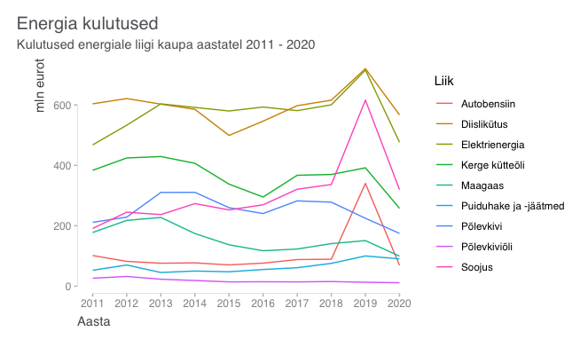

```r
data %>%
  filter(Liik %in% Liigid) %>%
  group_by(Aasta,Liik) %>%
  summarise(.groups="keep",Kokku = sum(Kogukulu)/1000) %>%
  ggplot(aes(x = Aasta, y = Kokku, color = Liik)) +
    geom_line() +
    theme_swd() +
    theme(
      axis.text.x = element_text(size = 9, color = GRAY7),
      axis.text.y = element_text(size = 9, color = GRAY7)
    ) +
    ylim(c(0, 8e5)) +
    xlim(c(2010, 2020)) +
    scale_x_continuous(breaks=seq(2011,2020,by=1)) +
    scale_y_continuous(labels=label_number()) +
    coord_capped_cart(bottom = 'both', left = "both")  +
    ylab("mln eurot") +
    xlab("Aasta") +
    ggtitle("Energia kulutused", subtitle = "Kulutused energiale liigi kaupa aastatel 2011 - 2020")
```

Üleval oleval joonisel näeme, et aasta 2019 kulutused erinevatele energialiikidele on tunduvalt suuremad. Huvitav, miks? Allpool teen kindlaks, et need tulenevad kodumajapidamiste kulutustest aastal 2019. Teiste aastate kohta lihtsalt kodumajapidamiste kohta andmeid pole. Seega vaatlen erinevaid ärivaldkondi ning kodumajapidamisi eraldi.

Summaarsed kulutused energia ja kütuseliikide lõikes:

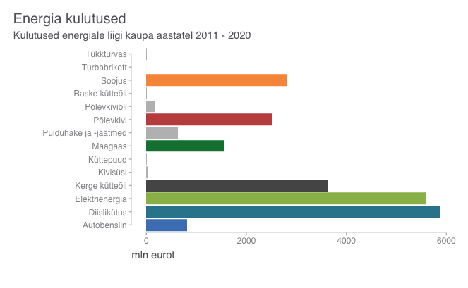

```r
liigi_kaupa = data %>%
  filter(Tegevusala != "Kodumajapidamine") %>%
  group_by(Liik) %>%
  summarise(.groups="keep",Kokku = sum(Kogukulu)/1000) %>%
  mutate(
    bar_color = case_when(
      Liik %in% c("Autobensiin") ~ BLUE2,
      Liik %in% c("Diislikütus") ~ GREEN3,
      Liik %in% c("Elektrienergia") ~ GREEN2,
      Liik %in% c("Soojus") ~ ORANGE1,
      Liik %in% c("Põlevkivi") ~ RED1,
      Liik %in% c("Kerge kütteõli") ~ GRAY3,
      Liik %in% c("Maagaas") ~ GREEN1,
      TRUE ~ GRAY9
    )
  )

ggplot(liigi_kaupa, aes(x = Kokku, y = Liik, fill = bar_color)) +
  geom_bar(stat = "identity") +
  coord_capped_cart(bottom = 'both', left = "both")  +
  ylab("") +
  xlab("mln eurot") +
  ggtitle("Energia kulutused", subtitle = "Kulutused energiale liigi kaupa aastatel 2011 - 2020") +
  scale_fill_identity() +
  theme_swd() +
  theme(
    axis.text.x = element_text(size = 9, color = GRAY7),
    axis.text.y = element_text(size = 9, color = GRAY7),
    legend.position = "none"
  )

ggsave("0_kõik_liigid.png", width = 9, height = 6)
```

Grupeeri liigi järgi ning kuva kogukulud energiale liigi kaupa üle aastate 2011-2020:

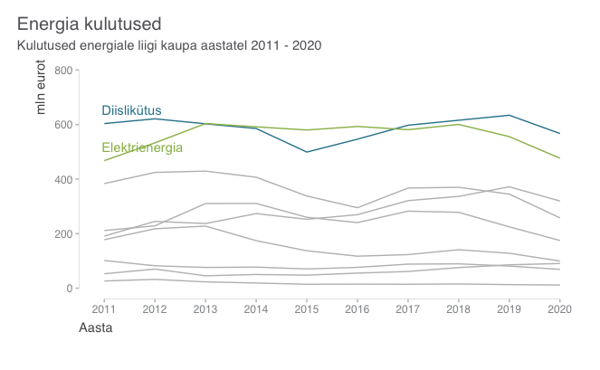

```r
liigi_kaupa = data %>%
  filter(Liik %in% Liigid) %>%
  filter(Tegevusala != "Kodumajapidamine") %>%
  group_by(Aasta,Liik) %>%
  summarise(.groups="keep",Kokku = sum(Kogukulu)/1000) %>%
  mutate(
    line_color = case_when(
      #Liik %in% c("Autobensiin") ~ BLUE2,
      Liik %in% c("Diislikütus") ~ GREEN3,
      Liik %in% c("Elektrienergia") ~ GREEN2,
      #Liik %in% c("Soojus") ~ ORANGE1,
      #Liik %in% c("Põlevkivi") ~ RED1,
      #Liik %in% c("Kerge kütteõli") ~ GRAY3,
      #Liik %in% c("Maagaas") ~ GREEN1,
      TRUE ~ GRAY9
    )
  )

labels = liigi_kaupa %>%
  filter(Liik %in% c("Diislikütus", "Elektrienergia")) %>%
  group_by(Liik) %>%
  filter(Aasta == 2011)

ggplot(liigi_kaupa, aes(x = Aasta, y = Kokku, group = Liik, color = line_color)) +
  geom_line() +
  geom_text(aes(x = Aasta, y = Kokku, label = Liik,color = line_color), hjust = 0, vjust = -1, nudge_x = -0.05, data = labels) +
  scale_x_continuous(breaks=seq(2011,2020,by=1)) +
  scale_y_continuous(labels=label_number()) +
  coord_capped_cart(bottom = 'both', left = "both")  +
  ylab("mln eurot") +
  xlab("Aasta") +
  ggtitle("Energia kulutused", subtitle = "Kulutused energiale liigi kaupa aastatel 2011 - 2020") +
  scale_color_identity() +
  theme_swd() +
  theme(
    axis.text.x = element_text(size = 9, color = GRAY7),
    axis.text.y = element_text(size = 9, color = GRAY7),
    legend.position = "none"
  ) +
  ylim(c(0, 800))
ggsave("1_liigiti.png")
```

Energia- ja kütuseliikide hinnad aastatel 2011 - 2020:

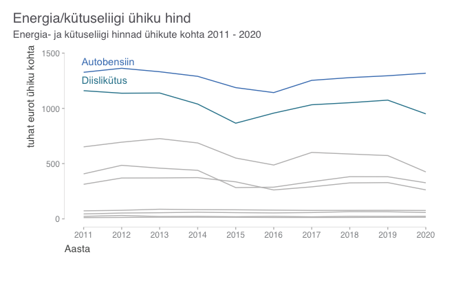

```r
hinnad = data %>%
  filter(Liik %in% Liigid) %>%
  filter(Tegevusala != "Kodumajapidamine") %>%
  select(Aasta,Liik,Ühikuhind) %>%
  group_by(Aasta,Liik) %>%
  summarize(.groups="keep", Üh_Hind = mean(Ühikuhind)) %>%
  mutate(
    line_color = case_when(
      Liik %in% c("Autobensiin") ~ BLUE2,
      Liik %in% c("Diislikütus") ~ GREEN3,
      #Liik %in% c("Elektrienergia") ~ GREEN2,
      #Liik %in% c("Soojus") ~ ORANGE1,
      #Liik %in% c("Põlevkivi") ~ RED1,
      #Liik %in% c("Kerge kütteõli") ~ GRAY3,
      #Liik %in% c("Maagaas") ~ GREEN1,
      TRUE ~ GRAY9
    )
  )

labels = hinnad %>%
  filter(Liik %in% c("Autobensiin", "Diislikütus")) %>%
  group_by(Liik) %>%
  filter(Aasta == 2011)


ggplot(hinnad, aes(x = Aasta, y = Üh_Hind, group = Liik, color = line_color)) +
  geom_line() +
  geom_text(aes(x = Aasta, y = Üh_Hind, label = Liik,color = line_color), hjust = 0, vjust = -1, nudge_x = -0.05, data = labels) +
  scale_x_continuous(breaks=seq(2011,2020,by=1)) +
  scale_y_continuous(labels=label_number()) +
  ylab("tuhat eurot ühiku kohta") +
  xlab("Aasta") +
  ggtitle("Energia/kütuseliigi ühiku hind", subtitle = "Energia- ja kütuseliigi hinnad ühikute kohta 2011 - 2020") +
  scale_color_identity() +
  theme_swd() +
  coord_capped_cart(bottom = 'both', left = "both")  +
  theme(
    axis.text.x = element_text(size = 9, color = GRAY7),
    axis.text.y = element_text(size = 9, color = GRAY7),
    legend.position = "none"
  ) +
  ylim(c(0, 1500))
ggsave("3_ühikuhind.png")
```

Üldine energia- ja kütuseliigi võrdlus 10 aasta (2011-2020) keskmise põhjal:

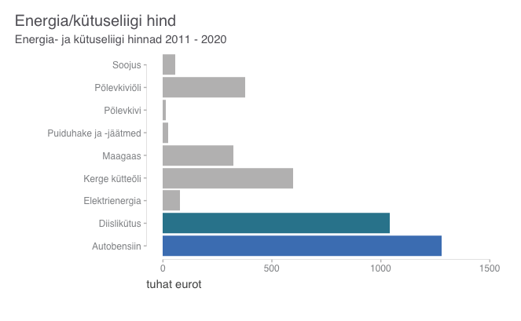

```r
hinnad = data %>%
  filter(Liik %in% Liigid) %>%
  filter(Tegevusala != "Kodumajapidamine") %>%
  select(Aasta,Liik,Ühikuhind) %>%
  group_by(Liik) %>%
  summarize(.groups="keep", Üh_Hind = mean(Ühikuhind)) %>%
  mutate(
    bar_color = case_when(
      Liik %in% c("Autobensiin") ~ BLUE2,
      Liik %in% c("Diislikütus") ~ GREEN3,
      TRUE ~ GRAY9
    )
  )


ggplot(hinnad, aes(x = Üh_Hind, y = Liik, fill = bar_color)) +
  geom_bar(stat = "identity",position = "dodge") +
  scale_fill_identity() +
  ylab("") +
  xlab("tuhat eurot") +
  ggtitle("Energia/kütuseliigi hind", subtitle = "Energia- ja kütuseliigi hinnad 2011 - 2020") +
  theme_swd() +
  coord_capped_cart(bottom = 'both', left = "both")  +
  theme(
    axis.text.x = element_text(size = 9, color = GRAY7),
    axis.text.y = element_text(size = 9, color = GRAY7),
    legend.position = "none"
  ) +
  xlim(c(0, 1500))

ggsave("4_keskm_ühikuhind.png")
```

Energia- ja kütuseliikide koguste võrdlused ajas, ühikuteks on 1000 tonni, 1000 tm, 1 mln m3, 1 GWh vastavate energialiikide puhul:

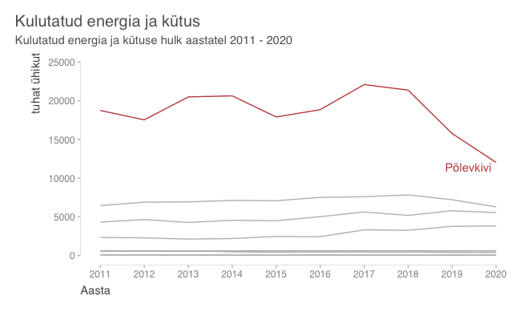

```r
hulgad = data %>%
  filter(Tegevusala != "Kodumajapidamine") %>%
  filter(Liik %in% Liigid) %>%
  select(Aasta,Liik,Kogus) %>%
  group_by(Aasta,Liik) %>%
  summarize(.groups="keep", Hulk = sum(Kogus)) %>%
  mutate(line_color = case_when(
      #Liik %in% c("Autobensiin") ~ BLUE2,
      #Liik %in% c("Diislikütus") ~ GREEN3,
      #Liik %in% c("Elektrienergia") ~ GREEN2,
      #Liik %in% c("Soojus") ~ ORANGE1,
      Liik %in% c("Põlevkivi") ~ RED1,
      #Liik %in% c("Kerge kütteõli") ~ GRAY3,
      #Liik %in% c("Maagaas") ~ GREEN1,
      TRUE ~ GRAY9
    ))

labels = hulgad %>%
  filter(Liik %in% c("Põlevkivi")) %>%
  group_by(Liik) %>%
  filter(Aasta == 2020)

  ggplot(hulgad,aes(x = Aasta, y = Hulk, group = Liik, color = line_color)) +
    geom_line() +
    geom_text(aes(x = Aasta, y = Hulk, label = Liik,color = line_color), hjust = 1, vjust = 1, nudge_x = -0.1, data = labels) +
    scale_x_continuous(breaks=seq(2011,2020,by=1)) +
    scale_y_continuous(labels=label_number()) +
    ylab("tuhat ühikut") +
    xlab("Aasta") +
    ggtitle("Kulutatud energia ja kütus", subtitle = "Kulutatud energia ja kütuse hulk aastatel 2011 - 2020") +
    scale_color_identity() +
    theme_swd() +
    coord_capped_cart(bottom = 'both', left = "both")  +
    theme(
      axis.text.x = element_text(size = 9, color = GRAY7),
      axis.text.y = element_text(size = 9, color = GRAY7),
      legend.position = "none"
    ) +
    ylim(c(0, 25000))
ggsave("2_kogused.png")
```

Üleval olevalt jooniselt näeme, et kõiki muid energia liike on võrdlemisi võrdselt tarbitud aastate 2011 - 2020 jooksul, kuid viimastel aastatel on langema hakanud põlevkivi tarbimine.

Energia- ja kütuseliikide võrdlemine tegevusvaldkondade lõikes:

Selleks lühendan tegevusvaldkondade nimetused:

```r
Alad = unique(data$Tegevusala)
length(Alad)
```

```
[1] 39
```

```r
Alad1 = Alad[1:13]
Alad2 = Alad[14:26]
Alad3 = Alad[27:39]


data = data %>%
  mutate(
    Ala = case_when(
    Tegevusala == "Turba tootmine ja muu kaevandamine" ~ "Turba tootmine",
    Tegevusala == "Toiduainete tootmine, joogitootmine" ~ "Toiduainetööstus",
    Tegevusala == "Tekstiili- ja rõivatootmine, nahatöötlemine ja nahktoodete tootmine" ~ "Tekstiilitööstus",
    Tegevusala == "Paberi ja pabertoodete tootmine, trükindus ja salvestiste paljundus" ~ "Paberitööstus-trükkimine",
    Tegevusala == "Koksi ja puhastatud naftatoodete tootmine" ~ "Koksi ja naftatoodete tootmine",
    Tegevusala == "keemia- ja farmaatsiatoodete tootmine" ~ "Farmaatsiatööstus",
    Tegevusala == "arvutite, elektriseadmete ja transpordivahendite tootmine" ~ "Elektroonikatööstus",
    Tegevusala == "Elektrienergia-, auru- ja kuumaveevarustus" ~ "Energia- ja veevarustus",
    Tegevusala == "Laondus, posti- ja kulleriteenistus" ~ "Laondus ja post",
    Tegevusala == "Muude mittemetalsetest mineraalidest toodete tootmine" ~ "Mineraaltooted",
    TRUE ~ Tegevusala
    )
  )
```

2019.a kulutused erinevatele energia/kütuse liikidele tegevusalade lõikes:

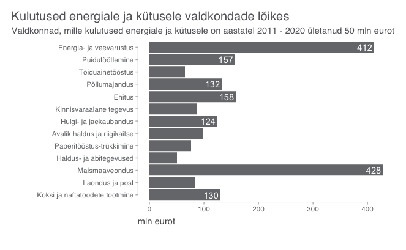

```r
teg = data %>%
  mutate(Ala = fct_reorder(Ala,Kogukulu)) %>%
  filter(Tegevusala != "Kodumajapidamine") %>%
  filter(Aasta == 2019) %>%
  group_by(Ala) %>%
  summarise(.groups="keep",Kokku = sum(Kogukulu)/1000) %>%
  filter(Kokku>50)

teg = teg %>%
  mutate(Ala = fct_reorder(Ala, Kokku, .desc = T))

ggplot(teg,
  aes(x = Kokku, y = Ala)) +
  geom_bar(stat = "identity", position = "dodge",fill = GRAY5) +
  geom_text(aes(label=round(Kokku)), color="white", hjust=1,nudge_x = -3,
            data= ~.x %>% filter(Ala %in%
                                   c("Energia- ja veevarustus",
                                     "Maismaaveondus",
                                     "Puidutöötlemine",
                                     "Ehitus",
                                     "Hulgi- ja jaekaubandus",
                                     "Koksi ja naftatoodete tootmine",
                                     "Põllumajandus"))) +
  ylab("") +
  xlab("mln eurot") +
  ggtitle("Kulutused energiale ja kütusele valdkondade lõikes", subtitle = "Valdkonnad, mille kulutused energiale ja kütusele on aastatel 2011 - 2020 ületanud 50 mln eurot") +
  coord_capped_cart(bottom = 'both', left = "both")  +
  #scale_y_discrete(labels = label_wrap(width = 40)) +
  theme_swd() +
  theme(
    legend.position = "none"
  )

ggsave("6_valdkonniti.png")
```

Üleval olevas tabelis leiduvad valdkonnad:

```r
Alad_suuremad = unique(teg$Ala)
```

Antud valdkondadest top6 täpsem kulutuste jaotus energia- ja kütuseliikide lõikes:

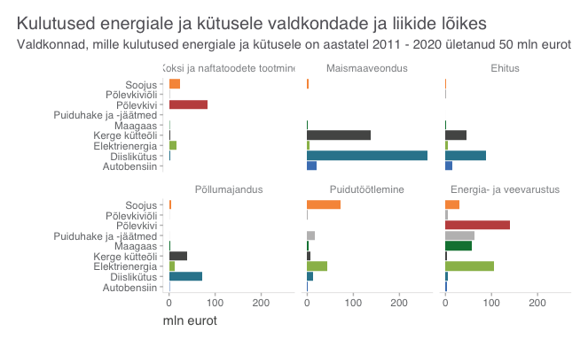

```r
teg = data %>%
  filter(Liik %in% Liigid) %>%
  filter(Ala %in% c("Energia- ja veevarustus", "Maismaaveondus",
                    "Puidutöötlemine","Ehitus",
                    "Koksi ja naftatoodete tootmine","Põllumajandus")) %>%
  mutate(Ala = fct_reorder(Ala,Kogukulu)) %>%
  filter(Tegevusala != "Kodumajapidamine") %>%
  filter(Aasta == 2019) %>%
  group_by(Ala, Liik) %>%
  summarise(.groups="keep",Kokku = sum(Kogukulu)/1000) %>%
  mutate(bar_color = case_when(
    Liik %in% c("Autobensiin") ~ BLUE2,
    Liik %in% c("Diislikütus") ~ GREEN3,
    Liik %in% c("Elektrienergia") ~ GREEN2,
    Liik %in% c("Soojus") ~ ORANGE1,
    Liik %in% c("Põlevkivi") ~ RED1,
    Liik %in% c("Kerge kütteõli") ~ GRAY3,
    Liik %in% c("Maagaas") ~ GREEN1,
    TRUE ~ GRAY9
  ))

teg = teg %>%
  mutate(Ala = fct_reorder(Ala, Kokku, .desc = T))

ggplot(teg,
  aes(x = Kokku, y = Liik, fill = bar_color)) +
  facet_wrap( ~ Ala) +
  geom_bar(stat = "identity", position = "dodge") +
  ylab("") +
  xlab("mln eurot") +
  ggtitle("Kulutused energiale ja kütusele valdkondade ja liikide lõikes", subtitle = "Valdkonnad, mille kulutused energiale ja kütusele on aastatel 2011 - 2020 ületanud 50 mln eurot") +
  scale_fill_identity() +
  theme_swd() +
  theme(
    legend.position = "none"
  )

ggsave("7_valdk_liigiti.png", width = 9, height = 6)
```

## Kodumajapidamiste energia kulutused

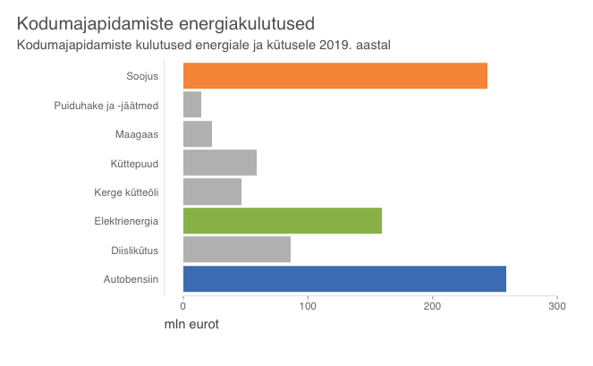

```r
data %>%
  #filter(Liik %in% Liigid) %>% <<<.... ei pane seda tingimust siia
  filter(Aasta == 2019) %>%
  filter(Tegevusala == "Kodumajapidamine") %>%
  group_by(Liik) %>%
  summarise(.groups="keep",Kokku = sum(Kogukulu)/1000) %>%
  filter(Kokku > 2) %>%
  mutate(Liik = fct_reorder(Liik,Kokku, .desc = T)) %>%
  mutate(bar_color = case_when(
    Liik %in% c("Autobensiin") ~ BLUE2,
    #Liik %in% c("Diislikütus") ~ GREEN3,
    Liik %in% c("Elektrienergia") ~ GREEN2,
    Liik %in% c("Soojus") ~ ORANGE1,
    #Liik %in% c("Põlevkivi") ~ RED1,
    #Liik %in% c("Kerge kütteõli") ~ GRAY3,
    #Liik %in% c("Maagaas") ~ GREEN1,
    TRUE ~ GRAY9
  )) %>%
  ggplot(aes(x = Kokku, y = Liik, fill = bar_color)) +
    geom_bar(stat = "identity", position = "dodge") +
    ylab("") +
    xlab("mln eurot") +
    scale_y_discrete(labels = label_wrap(width = 40)) +
    ggtitle("Kodumajapidamiste energiakulutused", subtitle = "Kodumajapidamiste kulutused energiale ja kütusele 2019. aastal") +
    coord_capped_cart(bottom = 'both')  +
    scale_fill_identity() +
    theme_swd() +
    theme(
      legend.position = "none",
      axis.ticks.y = element_blank()
    ) +
    xlim(0,300)

ggsave("5_kodumajapidamised.png")
```

## Energia ja kütuse andmed kaardil

```r
Maakonnad = c("Harju maakond", "Hiiu maakond", "Ida-Viru maakond", "Jõgeva maakond", "Järva maakond", "Lääne maakond", "Lääne-Viru maakond", "Põlva maakond", "Pärnu maakond", "Rapla maakond", "Saare maakond", "Tartu maakond", "Valga maakond", "Viljandi maakond", "Võru maakond")
Maakonnad
```

```
 [1] "Harju maakond"      "Hiiu maakond"       "Ida-Viru maakond"   "Jõgeva maakond"     "Järva maakond"      "Lääne maakond"      "Lääne-Viru maakond"
 [8] "Põlva maakond"      "Pärnu maakond"      "Rapla maakond"      "Saare maakond"      "Tartu maakond"      "Valga maakond"      "Viljandi maakond"
[15] "Võru maakond"
```

```r
load("eesti.RData", verbose = T)
```

```
Loading objects:
  vald
  maakond
  eesti
```

```r
maakond
```

|  | MNIMI | MKOOD | geometry |
| --- | --- | --- | --- |
| 1 | Saare maakond | 0074 |  |
| 2 | Viljandi maakond | 0084 |  |
| 3 | Hiiu maakond | 0039 |  |
| 4 | Harju maakond | 0037 |  |
| 5 | Lääne maakond | 0056 |  |
| 6 | Rapla maakond | 0071 |  |
| 7 | Ida-Viru maakond | 0045 |  |
| 8 | Valga maakond | 0081 |  |
| 9 | Tartu maakond | 0079 |  |
| 10 | Järva maakond | 0052 |  |

[output cut: 5 more lines]

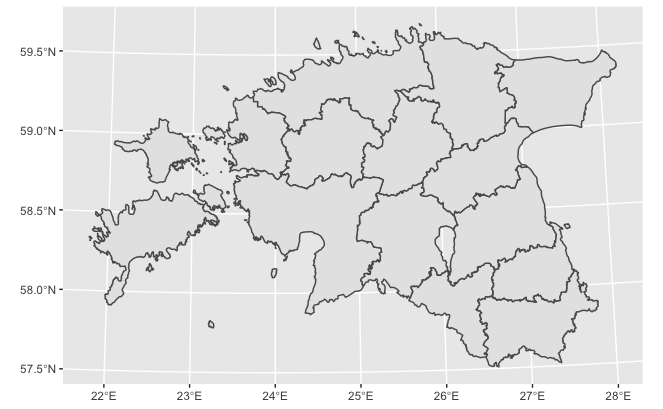

```r
ggplot(maakond) +
  geom_sf()
```

```r
mk_liik = data_mk %>%
  filter(Maakond %in% Maakonnad) %>%
  filter(Liik %in% Liigid) %>%
  group_by(Maakond,Liik) %>%
  summarise(.groups="keep",Kokku = sum(Kogukulu)/1000)
```

```r
kaardile = maakond %>%
  right_join(mk_liik %>% rename(MNIMI = Maakond))
kaardile
```

```
Simple feature collection with 135 features and 4 fields
Geometry type: MULTIPOLYGON
Dimension:     XY
Bounding box:  xmin: 369548.2 ymin: 6377146 xmax: 739149.6 ymax: 6617809
Projected CRS: Estonian Coordinate System of 1997
First 10 features:
              MNIMI MKOOD                  Liik     Kokku                       geometry
1     Saare maakond  0074           Autobensiin  58.42350 MULTIPOLYGON (((454431 6409...
2     Saare maakond  0074           Diislikütus 115.12888 MULTIPOLYGON (((454431 6409...
3     Saare maakond  0074        Elektrienergia  90.93811 MULTIPOLYGON (((454431 6409...
4     Saare maakond  0074        Kerge kütteõli   6.40381 MULTIPOLYGON (((454431 6409...
5     Saare maakond  0074               Maagaas   2.15792 MULTIPOLYGON (((454431 6409...
6     Saare maakond  0074 Puiduhake ja -jäätmed  12.62807 MULTIPOLYGON (((454431 6409...
7     Saare maakond  0074             Põlevkivi   0.00000 MULTIPOLYGON (((454431 6409...
8     Saare maakond  0074          Põlevkiviõli   5.86292 MULTIPOLYGON (((454431 6409...
9     Saare maakond  0074                Soojus  70.02951 MULTIPOLYGON (((454431 6409...
10 Viljandi maakond  0084           Autobensiin  93.65854 MULTIPOLYGON (((621348.6 64...
```

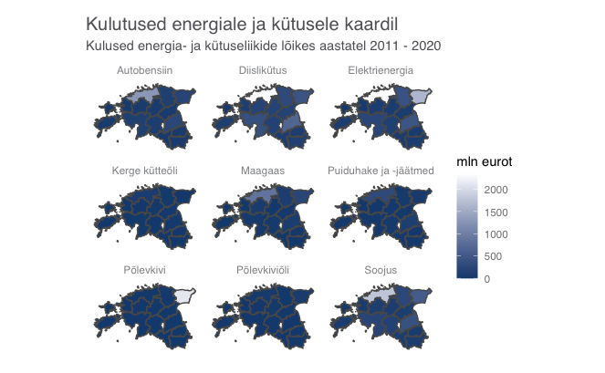

```r
ggplot(kaardile) + # vm on leftjoinitud maakond
  geom_sf(aes(fill = Kokku)) +
  facet_wrap(~Liik) +
  scale_fill_gradient("mln eurot", low = BLUE1, high = "white") +
  ggtitle("Kulutused energiale ja kütusele kaardil", subtitle = "Kulused energia- ja kütuseliikide lõikes aastatel 2011 - 2020") +
  theme_swd() +
  theme(
    axis.line = element_blank(),
    axis.text = element_blank(),
    axis.ticks.y = element_blank(),
    axis.ticks.x = element_blank(),
    legend.text = element_text(colour=GRAY6)
  )

ggsave("8_kaardil.png", width = 9, height = 6)
```

```r
Liigid
```

```
[1] "Soojus"                "Põlevkiviõli"          "Põlevkivi"             "Puiduhake ja -jäätmed" "Maagaas"               "Kerge kütteõli"
[7] "Elektrienergia"        "Diislikütus"           "Autobensiin"
```

```r
V = c(ORANGE1,GRAY9,RED1,GRAY9,GREEN1,GRAY9,GREEN2,GREEN3,BLUE2)

a = kaardile %>%
    filter(Liik == Liigid[1]) %>%
    ggplot() + # vm on leftjoinitud maakond
    geom_sf(aes(fill = Kokku)) +
    facet_wrap(~Liik) +
    scale_fill_gradient("mln eurot", low = V[1], high = "white") +
    theme_void() +
    theme(legend.position = "none")

b = kaardile %>%
    filter(Liik == Liigid[2]) %>%
    ggplot() + # vm on leftjoinitud maakond
    geom_sf(aes(fill = Kokku)) +
    facet_wrap(~Liik) +
    scale_fill_gradient("mln eurot", low = V[2], high = "white") +
    theme_void()+
    theme(legend.position = "none")

c = kaardile %>%
    filter(Liik == Liigid[3]) %>%
    ggplot() + # vm on leftjoinitud maakond
    geom_sf(aes(fill = Kokku)) +
    facet_wrap(~Liik) +
    scale_fill_gradient("mln eurot", low = V[3], high = "white") +
    theme_void()+
    theme(legend.position = "none")

d = kaardile %>%
    filter(Liik == Liigid[4]) %>%
    ggplot() + # vm on leftjoinitud maakond
    geom_sf(aes(fill = Kokku)) +
    facet_wrap(~Liik) +
    scale_fill_gradient("mln eurot", low = V[4], high = "white") +
    theme_void()+
    theme(legend.position = "none")

e = kaardile %>%
    filter(Liik == Liigid[5]) %>%
    ggplot() + # vm on leftjoinitud maakond
    geom_sf(aes(fill = Kokku)) +
    facet_wrap(~Liik) +
    scale_fill_gradient("mln eurot", low = V[5], high = "white") +
    theme_void()+
    theme(legend.position = "none")

f = kaardile %>%
    filter(Liik == Liigid[6]) %>%
    ggplot() + # vm on leftjoinitud maakond
    geom_sf(aes(fill = Kokku)) +
    facet_wrap(~Liik) +
    scale_fill_gradient("mln eurot", low = V[6], high = "white") +
    theme_void()+
    theme(legend.position = "none")

g = kaardile %>%
    filter(Liik == Liigid[7]) %>%
    ggplot() + # vm on leftjoinitud maakond
    geom_sf(aes(fill = Kokku)) +
    facet_wrap(~Liik) +
    scale_fill_gradient("mln eurot", low = V[7], high = "white") +
    theme_void()+
    theme(legend.position = "none")

h = kaardile %>%
    filter(Liik == Liigid[8]) %>%
    ggplot() + # vm on leftjoinitud maakond
    geom_sf(aes(fill = Kokku)) +
    facet_wrap(~Liik) +
    scale_fill_gradient("mln eurot", low = V[8], high = "white") +
    theme_void()+
    theme(legend.position = "none")

i = kaardile %>%
    filter(Liik == Liigid[9]) %>%
    ggplot() + # vm on leftjoinitud maakond
    geom_sf(aes(fill = Kokku)) +
    facet_wrap(~Liik) +
    scale_fill_gradient("mln eurot", low = V[9], high = "white") +
    theme_void()+
    theme(legend.position = "none")

(a | b | c ) / ( d | e | f ) / ( g | h | i ) +
  ggtitle("Kulutused energiale ja kütusele kaardil", subtitle = "Kulused energia- ja kütuseliikide lõikes aastatel 2011 - 2020") +
  theme_swd +
  theme(
    axis.line = element_blank(),
    axis.text = element_blank(),
    axis.ticks.y = element_blank(),
    axis.ticks.x = element_blank()
  )
```

[output not shown]